# What do UFOs look like?

Dr Pravin Jeyaraj

30 January 2018

Source: NUFORC/Kaggle https://www.kaggle.com/NUFORC/ufo-sightings/data

```r
library(tm)
```

# The shape of UFOs?

```r
shape.canttell
```

[output not shown]

According to the dataset, there are 27 possible recognisable forms that a UFO can take, such as a dome, a hexagon, a pyramid, an egg, a cigar and so on. The most common observed form of UFO by far, at over 16,000, is a light - this is about twice as common than the second most observed form, a triangle.

Of course, if my knowledge of science fiction TV has taught me anything, just seeing a light could simply mean that the observation was at night time and, with the lights on, it was too dark to see anything much of the shape. Like when you are driving at night and a car is heading toward you from the opposite direction - the headlights are always the first thing you see, long before you see the actual chassis.

```r
shape.canttell = sum(ufo_data$UFO_shape == "unknown" | ufo_data$UFO_shape == "other" | ufo_data$UFO_shape == "")
shape.canttell
```

However, the shape of 13,165 observations are recorded as “unknown”, “other” or not specified. In other words, in actuality, it is not possible to tell the shape of a significant of number of UFO observations recorded by NUFORC. Therefore, it is quite possible that the numbers are subject to bias. For this reason, the values for “unknown”, “other” and " " have been added together into an umbrella category “can’t tell”

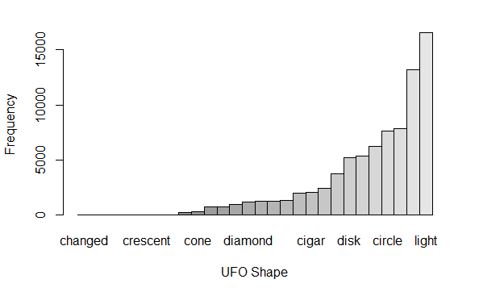

# How do the shape of observed UFOs differ across countries?

```r
ufo_shape.country
```

```
                     au    ca    de    gb    us
              271    11    45     2    50  1553
  changed       0     0     0     0     0     1
  changing    252     9    69     2    46  1584
  chevron      89     3    36     1     8   815
  cigar       262    15    74     3    60  1643
  circle      891    62   284    10   243  6118
  cone         40     6    10     0    13   247
  crescent      1     0     0     0     0     1
  cross        25     1     9     0    10   188
  cylinder    161     9    53     3    30  1027
  delta         0     0     1     0     0     6
  diamond     154    10    40     3    43   928
  disk        736    50   198     6   102  4121
  dome          1     0     0     0     0     0
  egg         105    12    28     1    32   581
  fireball    682    34   218     9   117  5148
  flare         0     0     0     0     0     1
  flash       174     4    62     1    25  1062
  formation   286    20    98     3    60  1990
  hexagon       0     0     0     0     0     1
  light      1937   119   655    20   361 13473
  other       760    40   241     9   133  4466
  oval        448    30   130     7    86  3032
  pyramid       0     0     0     0     0     1
  rectangle   140    10    47     1    29  1070
  round         0     0     0     0     0     2
  sphere      655    15   205     7   158  4347
  teardrop     88    10    22     0    38   592
  triangle    827    43   268     9   169  6549
  unknown     685    25   207     8    92  4567
```

## distribution of most common shapes accross the US

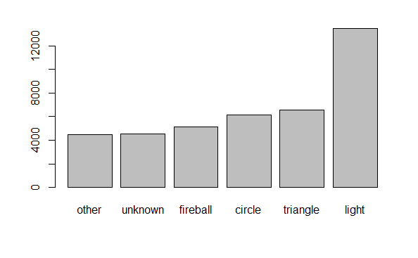

## distribution of most common shapes across Great Britain

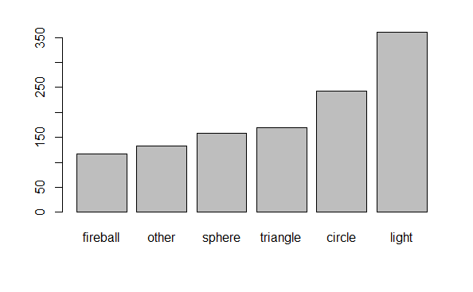

[figure not shown]

## distribution of most common shapes across Canada

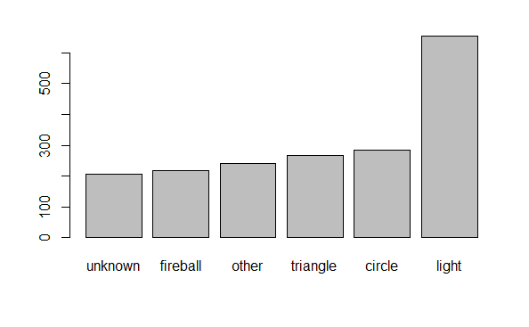

## distribution of most common shapes across Australia

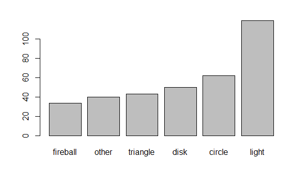

Generally speaking, “light”, “triangle”, “circle”, “fireball” and “cannot tell” can be said to be most common form of UFOs observed. However, in Britain, the “sphere” shape has been observed particularly in Britain and the “disk” shape observed particularly in Australia (relative to other areas).